# DT_Post_Pruning_low_animation

### Decision Tree Pruning

###### Definition:

In machine learning and data mining, pruning is a technique associated with decision trees. Pruning reduces the size of decision trees by removing parts of the tree that do not provide power to classify instances. Decision trees are the most susceptible out of all the machine learning algorithms to overfitting, and effective pruning can reduce this likelihood. We will go over two techniques to help with overfitting :-

1. pre-pruning or early stopping
2. post-pruning

Let's first understand how overfitting and underfitting happens in Decision Trees. When the decision tree model memorizes its training data so well that it is learning noise on top of the signal, then it is actually overfitting. Generally in this case the decision tree is very long and a leaves can contain very less number of instances( as less as one single instance). And when the tree is too short and simple to learn pattern in data. So the aim of the decison tree pruning is to balance between the simplicity and the accuracy.

### Post Pruning by removing nodes which does not contribute to improve accuracy:

```python
import numpy as np
from sklearn.datasets import load_iris
from sklearn import tree
import pandas as pd
from sklearn.model_selection import train_test_split
from sklearn.metrics import accuracy_score
import graphviz
import pydot
import imageio
from PIL import Image
```

```python
diabetes=pd.read_csv('diabetes.csv')
print(diabetes.head(5))
```

```
   Pregnancies  Glucose  BloodPressure  SkinThickness  Insulin   BMI  \
0            6      148             72             35        0  33.6
1            1       85             66             29        0  26.6
2            8      183             64              0        0  23.3
3            1       89             66             23       94  28.1
4            0      137             40             35      168  43.1

   DiabetesPedigreeFunction  Age  Outcome
0                     0.627   50        1
1                     0.351   31        0
2                     0.672   32        1
3                     0.167   21        0
4                     2.288   33        1
```

```python
d = diabetes.drop("Outcome" ,axis=1)
y = diabetes['Outcome'].apply(str)
#print("x.shape={0}, y.shape={1}".format(d.shape, y.shape))
x_train, x_test, y_train, y_test = train_test_split(d, y , test_size=0.2, stratify=y, random_state=1)
#print("x_train.shape={0}, y_train.shape={1}".format(x_train.shape, y_train.shape))
x_train, x_vald, y_train, y_vald = train_test_split(x_train, y_train, test_size=0.3, stratify=y_train,  random_state=1)
#print("x_train.shape={0}, y_train.shape={1}".format(x_train.shape, y_train.shape))

clf = tree.DecisionTreeClassifier(criterion='entropy',max_depth = None,min_samples_leaf=1)
clf = clf.fit(x_train,y_train)
# prediction = clf.predict(x_vald)
#print("prediction= ",prediction)
vald_score=clf.score(x_vald,y_vald)
print("Validation Score before pruning= ",vald_score)
# before_pruning_score=score
best_score=vald_score

test_score=clf.score(x_test,y_test)
print("Test Score before pruning= ",test_score)



n_nodes = clf.tree_.node_count
print("Number of nodes: ",n_nodes)
#print(clf.apply(x_test))
#print(clf.tree_.value)
```

```
Validation Score before pruning=  0.7135135135135136
Test Score before pruning=  0.6818181818181818
Number of nodes:  147
```

```python
images=[]
dot_data = tree.export_graphviz(clf, out_file=None)
graph = graphviz.Source(dot_data)
graph.render("diabetes_Tree.dot")
print(list(x_train))
dot_data = tree.export_graphviz(clf, out_file=None,
                      feature_names=list(x_train),
                      class_names=list(y_train),
                      filled=True, rounded=True,
                      special_characters=True)
graph1 = graphviz.Source(dot_data)

import pydot
(graph,) = pydot.graph_from_dot_file("diabetes_Tree.dot")
graph.write_png('Diabetes_Tree.png')
filename="Diabetes_Tree.png"
img = Image.open(filename)
img=img.resize((1000,800))
img.save(filename)
images.append(imageio.imread(filename))

graph1
```

```
['Pregnancies', 'Glucose', 'BloodPressure', 'SkinThickness', 'Insulin', 'BMI', 'DiabetesPedigreeFunction', 'Age']
```

[figure not shown]

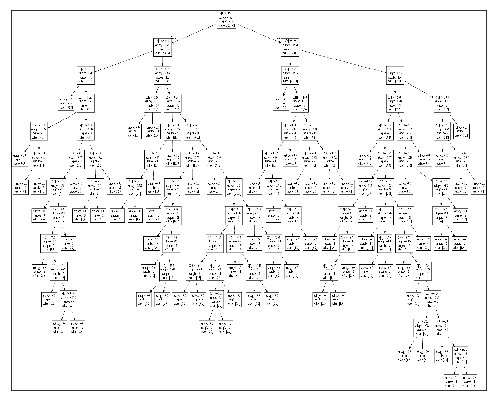

```python
%pylab inline
import matplotlib.pyplot as plt
%matplotlib inline
plt.rcParams["figure.figsize"] = [15,7]
import matplotlib.image as mpimg
img=mpimg.imread('Diabetes_Tree.png')
imgplot = plt.imshow(img)
plt.xticks([])
plt.yticks([])
plt.show()
```

```python
def num_nodes(clf_local, n):
    if(n!=-1):
        nodes=1
    else:
        return 0
    left_nodes=num_nodes(clf_local, clf_local.tree_.children_left[n])
    right_nodes=num_nodes(clf_local, clf_local.tree_.children_right[n])
    nodes=nodes+left_nodes+right_nodes
    return nodes

prune_nodes=[]
clf = tree.DecisionTreeClassifier(criterion='entropy',max_depth = None,min_samples_leaf=1)
clf = clf.fit(x_train,y_train)
clf_local=clf

for i in range(n_nodes-1,0,-1):
#     try:
    clf_local=clf

    if clf_local.tree_.children_left[i]!=clf_local.tree_.children_right[i]:
        clf_local.tree_.children_left[i]=-1
        clf_local.tree_.children_right[i]=-1
        score_local=clf_local.score(x_vald,y_vald)
        if(score_local>=best_score):
            print("Pruning by removing all childs of node number {0} improves validation accuracy from {1} to {2}".format(i, best_score, score_local))
            print("Test accuracy after this pruning: ",clf_local.score(x_test,y_test))
            print("Number of nodes: ",num_nodes(clf_local, 0))
            prune_nodes.append(i)
            best_score=score_local
            clf=clf_local

            dot_data_local = tree.export_graphviz(clf_local, out_file=None)
            graph_local = graphviz.Source(dot_data_local)
            graph_local.render("diabetes_Tree_"+str(i)+".dot")
            #print(list(x_train))
            dot_data_local = tree.export_graphviz(clf_local, out_file=None,
                                  feature_names=list(x_train),
                                  class_names=list(y_train),
                                  filled=True, rounded=True,
                                  special_characters=True)
            graph1_local = graphviz.Source(dot_data_local)


            (graph_local,) = pydot.graph_from_dot_file("diabetes_Tree_"+str(i)+".dot")
            graph_local.write_png("Diabetes_Tree_"+str(i)+".png")
            filename="Diabetes_Tree_"+str(i)+".png"
            img = Image.open(filename)
            img=img.resize((1000,800))
            img.save(filename)
            images.append(imageio.imread(filename))

            print("New tree: --------------------------------------")
            graph1_local

        else:
            clf = tree.DecisionTreeClassifier(criterion='entropy',max_depth = None,min_samples_leaf=1)
            clf = clf.fit(x_train,y_train)
            if len(prune_nodes)>0:
                for j in prune_nodes:
                    clf.tree_.children_left[j]=-1
                    clf.tree_.children_right[j]=-1
#     except:
#         pass

after_pruning_score=score_local
imageio.mimsave("DT_Pruning_low.gif", images, duration=0.5)
```

```
Pruning by removing all childs of node number 140 improves validation accuracy from 0.7135135135135136 to 0.7135135135135136
Test accuracy after this pruning:  0.7142857142857143
Number of nodes:  141
New tree: --------------------------------------
Pruning by removing all childs of node number 135 improves validation accuracy from 0.7135135135135136 to 0.7135135135135136
Test accuracy after this pruning:  0.7142857142857143
Number of nodes:  139
New tree: --------------------------------------
Pruning by removing all childs of node number 134 improves validation accuracy from 0.7135135135135136 to 0.7135135135135136
Test accuracy after this pruning:  0.7077922077922078
Number of nodes:  137
New tree: --------------------------------------
Pruning by removing all childs of node number 132 improves validation accuracy from 0.7135135135135136 to 0.7135135135135136
Test accuracy after this pruning:  0.7077922077922078
Number of nodes:  135
New tree: --------------------------------------
Pruning by removing all childs of node number 131 improves validation accuracy from 0.7135135135135136 to 0.7135135135135136
Test accuracy after this pruning:  0.7077922077922078
Number of nodes:  133
New tree: --------------------------------------
Pruning by removing all childs of node number 119 improves validation accuracy from 0.7135135135135136 to 0.7189189189189189
Test accuracy after this pruning:  0.7142857142857143
Number of nodes:  131
New tree: --------------------------------------
Pruning by removing all childs of node number 117 improves validation accuracy from 0.7189189189189189 to 0.7189189189189189
Test accuracy after this pruning:  0.7142857142857143
Number of nodes:  129
New tree: --------------------------------------
Pruning by removing all childs of node number 116 improves validation accuracy from 0.7189189189189189 to 0.7189189189189189
Test accuracy after this pruning:  0.7142857142857143
Number of nodes:  127
New tree: --------------------------------------
Pruning by removing all childs of node number 113 improves validation accuracy from 0.7189189189189189 to 0.7243243243243244
Test accuracy after this pruning:  0.7012987012987013
Number of nodes:  125
New tree: --------------------------------------
Pruning by removing all childs of node number 106 improves validation accuracy from 0.7243243243243244 to 0.7297297297297297
Test accuracy after this pruning:  0.7012987012987013
Number of nodes:  115
New tree: --------------------------------------
```

[output cut: 33 more lines]

```
Test accuracy after this pruning:  0.7337662337662337
Number of nodes:  77
New tree: --------------------------------------
Pruning by removing all childs of node number 25 improves validation accuracy from 0.7513513513513513 to 0.7513513513513513
Test accuracy after this pruning:  0.7337662337662337
Number of nodes:  75
New tree: --------------------------------------
Pruning by removing all childs of node number 24 improves validation accuracy from 0.7513513513513513 to 0.7513513513513513
Test accuracy after this pruning:  0.7337662337662337
Number of nodes:  73
New tree: --------------------------------------
Pruning by removing all childs of node number 17 improves validation accuracy from 0.7513513513513513 to 0.7513513513513513
Test accuracy after this pruning:  0.7337662337662337
Number of nodes:  71
New tree: --------------------------------------
```

```python
import graphviz
dot_data = tree.export_graphviz(clf_local, out_file=None)

graph = graphviz.Source(dot_data)
#graph.render("Iris_Dataset_Backup - Graph.csv")
graph.render("diabetes_Tree1.dot")

print(list(x_train))
dot_data = tree.export_graphviz(clf_local, out_file=None,
                      feature_names=list(x_train),
                      class_names=list(y_train),
                      filled=True, rounded=True,
                      special_characters=True)

graph1 = graphviz.Source(dot_data)

# import pydot
# (graph,) = pydot.graph_from_dot_file("diabetes_Tree.dot")
# graph.write_png('Diabetes_Tree.png')

graph1
# print("done")
```

```
['Pregnancies', 'Glucose', 'BloodPressure', 'SkinThickness', 'Insulin', 'BMI', 'DiabetesPedigreeFunction', 'Age']
```

[figure not shown]

```python
from imgurpython import ImgurClient

client_id = 'ad82055147613f2'
client_secret = 'f615cff60ada1fa6a7111c717876e72854efaf8c'

client = ImgurClient(client_id, client_secret)

response=client.upload_from_path("DT_Pruning_low.gif", config=None, anon=True)
link=response['link']
print(link)
```

```
https://i.imgur.com/hIAYpYE.gif
```

```python
def display_gif(fn):
    from IPython import display
    return display.HTML('<img src="{}">'.format(fn))

display_gif(link)
```

[figure not shown]

```python
import numpy as np
from sklearn import tree
import pandas as pd
from sklearn.model_selection import train_test_split
from sklearn.metrics import accuracy_score
import imageio
from PIL import Image
import graphviz
import pydot
```

```python
diabetes=pd.read_csv('diabetes.csv')
d = diabetes.drop("Outcome" ,axis=1)
y = diabetes['Outcome'].apply(str)
x_train, x_test, y_train, y_test = train_test_split(d, y , test_size=0.2, stratify=y, random_state=1)
x_train, x_vald, y_train, y_vald = train_test_split(x_train, y_train , test_size=0.3, stratify=y_train, random_state=1)
clf = tree.DecisionTreeClassifier(criterion='entropy',max_depth = None,min_samples_leaf=1)
clf = clf.fit(x_train,y_train)
vald_score=clf.score(x_vald,y_vald)
best_score2=vald_score
test_score=clf.score(x_test,y_test)
print("Validation Score without Pre-Pruning = ",vald_score)
print("Test Score without Pre-Pruning = ",test_score)
n_nodes = clf.tree_.node_count
print("Number of nodes: ",n_nodes)
```

```
Validation Score without Pre-Pruning =  0.6918918918918919
Test Score without Pre-Pruning =  0.7142857142857143
Number of nodes:  147
```

```python
dot_data = tree.export_graphviz(clf, out_file=None)
graph = graphviz.Source(dot_data)
#graph.render("Iris_Dataset_Backup - Graph.csv")
graph.render("diabetes_Tree2_pre_minsample.dot")
print(list(x_train))
dot_data = tree.export_graphviz(clf, out_file=None,
                      feature_names=list(x_train),
                      class_names=list(y_train),
                      filled=True, rounded=True,
                      special_characters=True)
graph1 = graphviz.Source(dot_data)

images = []
(graph,) = pydot.graph_from_dot_file("diabetes_Tree2_pre_minsample.dot")
graph.write_png('diabetes_Tree2_pre_minsample.png')
filename="diabetes_Tree2_pre_minsample.png"
img = Image.open(filename)
img=img.resize((1600,1000))
img.save(filename)
images.append(imageio.imread(filename))

graph1
```

```
['Pregnancies', 'Glucose', 'BloodPressure', 'SkinThickness', 'Insulin', 'BMI', 'DiabetesPedigreeFunction', 'Age']
```

[figure not shown]

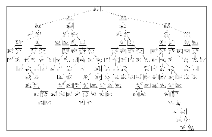

```python
%pylab inline
import matplotlib.pyplot as plt
import matplotlib.image as mpimg
img=mpimg.imread('diabetes_Tree2_pre_minsample.png')
imgplot = plt.imshow(img)
plt.xticks([])
plt.yticks([])
plt.show()
```

```python
for i in range(1,10):
    clf1 = tree.DecisionTreeClassifier(criterion='entropy',max_depth = None,min_samples_leaf=i)
    clf1 = clf1.fit(x_train,y_train)
    score1=clf1.score(x_vald,y_vald)
    if(score1 > best_score2):
        print("\nNew tree: --------------------------------------")
        print("Improved Validation Score from {0} to {1} for min samples leaf {2}".format(best_score2, score1, i))
        score2=clf1.score(x_test,y_test)
        print("Test Score= {0} ".format(score2))
        n_nodes1 = clf1.tree_.node_count
        print("Number of nodes: ",n_nodes1)
        best_score2 = score1
        clf_local = clf1
        dot_data_local = tree.export_graphviz(clf_local, out_file=None)
        graph_local = graphviz.Source(dot_data_local)
        graph_local.render("diabetes_Tree2_pre_minsample"+str(i)+".dot")
        #print(list(x_train))
        dot_data_local = tree.export_graphviz(clf_local, out_file=None,
                              feature_names=list(x_train),
                              class_names=list(y_train),
                              filled=True, rounded=True,
                              special_characters=True)
        graph1_local = graphviz.Source(dot_data_local)


        (graph_local,) = pydot.graph_from_dot_file("diabetes_Tree2_pre_minsample"+str(i)+".dot")
        graph_local.write_png("diabetes_Tree2_pre_minsample"+str(i)+".png")
        filename="diabetes_Tree2_pre_minsample"+str(i)+".png"
        img = Image.open(filename)
        img=img.resize((1600,1000))
        img.save(filename)
        images.append(imageio.imread(filename))
        graph1_local

imageio.mimsave("DT_Pruning_2_pre_minsample.gif", images, duration=0.5)
print("\nFinally, After Pre Pruning Validation accuracy is: ",best_score2)
print("After Pre Pruning Test accuracy is: ",clf_local.score(x_test,y_test))
```

```
New tree: --------------------------------------
Improved Validation Score from 0.6918918918918919 to 0.7081081081081081 for min samples leaf 1
Test Score= 0.7337662337662337
Number of nodes:  149

New tree: --------------------------------------
Improved Validation Score from 0.7081081081081081 to 0.7243243243243244 for min samples leaf 6
Test Score= 0.7467532467532467
Number of nodes:  77

New tree: --------------------------------------
Improved Validation Score from 0.7243243243243244 to 0.745945945945946 for min samples leaf 7
Test Score= 0.7662337662337663
Number of nodes:  69

New tree: --------------------------------------
Improved Validation Score from 0.745945945945946 to 0.7567567567567568 for min samples leaf 8
Test Score= 0.7532467532467533
Number of nodes:  65

Finally, After Pre Pruning Validation accuracy is:  0.7567567567567568
After Pre Pruning Test accuracy is:  0.7532467532467533
```

```python
dot_data = tree.export_graphviz(clf_local, out_file=None)
graph = graphviz.Source(dot_data)
graph.render("diabetes_Tree2_pre_minsample.dot")
dot_data = tree.export_graphviz(clf_local, out_file=None,
                      feature_names=list(x_train),
                      class_names=list(y_train),
                      filled=True, rounded=True,
                      special_characters=True)
graph1 = graphviz.Source(dot_data)

graph1
```

[figure not shown]

```python
from imgurpython import ImgurClient

client_id = 'ad82055147613f2'
client_secret = 'f615cff60ada1fa6a7111c717876e72854efaf8c'

client = ImgurClient(client_id, client_secret)

response=client.upload_from_path("DT_Pruning_2_pre_minsample.gif", config=None, anon=True)
link=response['link']
print(link)
```

```
https://i.imgur.com/ymQmwKf.gif
```

```python
def display_gif(fn):
    from IPython import display
    return display.HTML('<img src="{}">'.format(fn))

display_gif(link)
```

[figure not shown]

### Pre Pruning By applying constraing on the Height of Tree:

```python
import numpy as np
from sklearn import tree
import pandas as pd
from sklearn.model_selection import train_test_split
from sklearn.metrics import accuracy_score
import imageio
from PIL import Image
import graphviz
import pydot
```

```python
diabetes=pd.read_csv('diabetes.csv')
d = diabetes.drop("Outcome" ,axis=1)
y = diabetes['Outcome'].apply(str)
x_train, x_test, y_train, y_test = train_test_split(d, y , test_size=0.2,  random_state=1)
x_train, x_vald, y_train, y_vald = train_test_split(x_train, y_train , test_size=0.3, random_state=1)
clf = tree.DecisionTreeClassifier(criterion='entropy',max_depth = None,min_samples_leaf=1)
clf = clf.fit(x_train,y_train)
vald_score=clf.score(x_vald,y_vald)
best_score1=vald_score
test_score=clf.score(x_test,y_test)
print("Validation Score without Pre-Pruning = ",vald_score)
print("Test Score without Pre-Pruning = ",test_score)
n_nodes = clf.tree_.node_count
print("Number of nodes: ",n_nodes)
children_left = clf.tree_.children_left
children_right = clf.tree_.children_right
feature = clf.tree_.feature
threshold = clf.tree_.threshold
```

```
Validation Score without Pre-Pruning =  0.6810810810810811
Test Score without Pre-Pruning =  0.7012987012987013
Number of nodes:  165
```

```python
dot_data = tree.export_graphviz(clf, out_file=None)
graph = graphviz.Source(dot_data)
#graph.render("Iris_Dataset_Backup - Graph.csv")
graph.render("diabetes_Tree_pre_height.dot")
print(list(x_train))
dot_data = tree.export_graphviz(clf, out_file=None,
                      feature_names=list(x_train),
                      class_names=list(y_train),
                      filled=True, rounded=True,
                      special_characters=True)
graph1 = graphviz.Source(dot_data)

images = []
(graph,) = pydot.graph_from_dot_file("diabetes_Tree_pre_height.dot")
graph.write_png('diabetes_Tree_pre_height.png')
filename="diabetes_Tree_pre_height.png"
img = Image.open(filename)
img=img.resize((1600,1000))
img.save(filename)
images.append(imageio.imread(filename))

graph1
```

```
['Pregnancies', 'Glucose', 'BloodPressure', 'SkinThickness', 'Insulin', 'BMI', 'DiabetesPedigreeFunction', 'Age']
```

[figure not shown]

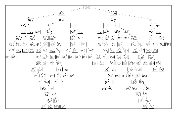

```python
%pylab inline
import matplotlib.pyplot as plt
import matplotlib.image as mpimg
img=mpimg.imread('diabetes_Tree_pre_height.png')
imgplot = plt.imshow(img)
plt.xticks([])
plt.yticks([])
plt.show()
```

```python
node_depth = np.zeros(shape=n_nodes, dtype=np.int64)
is_leaves = np.zeros(shape=n_nodes, dtype=bool)
stack = [(0, -1)]  # seed is the root node id and its parent depth
while len(stack) > 0:
    node_id, parent_depth = stack.pop()
    node_depth[node_id] = parent_depth + 1

    # If we have a test node
    if (children_left[node_id] != children_right[node_id]):
        stack.append((children_left[node_id], parent_depth + 1))
        stack.append((children_right[node_id], parent_depth + 1))
    else:
        is_leaves[node_id] = True
max_Depth = max(node_depth)
print("Max Depth is",max_Depth)
```

```
Max Depth is 16
```

```python
for i in range(max_Depth,5,-1):
    clf1 = tree.DecisionTreeClassifier(criterion='entropy',max_depth = i,min_samples_leaf=1)
    clf1 = clf1.fit(x_train,y_train)
    score1=clf1.score(x_vald,y_vald)
    if(score1 > best_score1):
        print("\nNew tree: --------------------------------------")
        print("Improved Validation Score from {0} to {1} for height {2}".format(best_score1, score1, i))
        score2=clf1.score(x_test,y_test)
        print("Test Score = {0} ".format(score2))
        n_nodes1 = clf1.tree_.node_count
        print("Number of nodes: ",n_nodes1)
        best_score1 = score1
        clf_local = clf1
        dot_data_local = tree.export_graphviz(clf_local, out_file=None)
        graph_local = graphviz.Source(dot_data_local)
        graph_local.render("diabetes_Tree_pre_height"+str(i)+".dot")
        #print(list(x_train))
        dot_data_local = tree.export_graphviz(clf_local, out_file=None,
                              feature_names=list(x_train),
                              class_names=list(y_train),
                              filled=True, rounded=True,
                              special_characters=True)
        graph1_local = graphviz.Source(dot_data_local)


        (graph_local,) = pydot.graph_from_dot_file("diabetes_Tree_pre_height"+str(i)+".dot")
        graph_local.write_png("diabetes_Tree_pre_height"+str(i)+".png")
        filename="diabetes_Tree_pre_height"+str(i)+".png"
        img = Image.open(filename)
        img=img.resize((1600,1000))
        img.save(filename)
        images.append(imageio.imread(filename))
        graph1_local

imageio.mimsave("DT_Pruning_low_pre_height.gif", images, duration=0.5)
print("\nFinally, After Pre Pruning Validation accuracy is: ",best_score1)
print("After Pre Pruning Test accuracy is: ",clf_local.score(x_test,y_test))
```

```
New tree: --------------------------------------
Improved Validation Score from 0.6810810810810811 to 0.6972972972972973 for height 15
Test Score = 0.7337662337662337
Number of nodes:  161

New tree: --------------------------------------
Improved Validation Score from 0.6972972972972973 to 0.7027027027027027 for height 14
Test Score = 0.7077922077922078
Number of nodes:  161

New tree: --------------------------------------
Improved Validation Score from 0.7027027027027027 to 0.7135135135135136 for height 8
Test Score = 0.7467532467532467
Number of nodes:  91

New tree: --------------------------------------
Improved Validation Score from 0.7135135135135136 to 0.7243243243243244 for height 7
Test Score = 0.7207792207792207
Number of nodes:  81

Finally, After Pre Pruning Validation accuracy is:  0.7243243243243244
After Pre Pruning Test accuracy is:  0.7207792207792207
```

```python
dot_data = tree.export_graphviz(clf_local, out_file=None)
graph = graphviz.Source(dot_data)
graph.render("diabetes_Tree1_pre_height.dot")
dot_data = tree.export_graphviz(clf_local, out_file=None,
                      feature_names=list(x_train),
                      class_names=list(y_train),
                      filled=True, rounded=True,
                      special_characters=True)
graph1 = graphviz.Source(dot_data)

graph1
```

[figure not shown]

```python
from imgurpython import ImgurClient

client_id = 'ad82055147613f2'
client_secret = 'f615cff60ada1fa6a7111c717876e72854efaf8c'

client = ImgurClient(client_id, client_secret)

response=client.upload_from_path("DT_Pruning_low_pre_height.gif", config=None, anon=True)
link=response['link']
print(link)
```

```
https://i.imgur.com/pknEFue.gif
```

```python
def display_gif(fn):
    from IPython import display
    return display.HTML('<img src="{}">'.format(fn))

display_gif(link)
```

[figure not shown]

If the animation is not visibile in your device plese click here to view a demo animation: https://drive.google.com/open?id=1hdtOMI9efYj75BA7EBo8To_ujFXz0TF5

References:

[1] https://www.displayr.com/machine-learning-pruning-decision-trees/ . [Accessed: April 01, 2019]

[2] https://acadgild.com/blog/decision-tree-python-code . [Accessed: April 03, 2019]

[3] https://scikit-learn.org/stable/auto_examples/tree/plot_unveil_tree_structure.html . [Accessed: April 04, 2019]